# dlookr: Data Transformation

package

dlookr

Transformation

Introduction to data fransformation in the dlookr package

Choonghyun Ryu  
05-12-2021

# Preface

After you have acquired the data, you should do the following:

- Diagnose data quality.
  - If there is a problem with data quality,
  - The data must be corrected or re-acquired.
- Explore data to understand the data and find scenarios for performing the analysis.
- **Derive new variables or perform variable transformations.**

The dlookr package makes these steps fast and easy:

- Performs a data diagnosis or automatically generates a data diagnosis report.
- Discover data in a variety of ways, and automatically generate EDA(exploratory data analysis) report.
- **Impute missing values and outliers, resolve skewed data, and binaries continuous variables into categorical variables. And generates an automated report to support it.**

This document introduces **data transformation** methods provided by the dlookr package. You will learn how to transform of `tbl_df` data that inherits from data.frame and `data.frame` with functions provided by dlookr.

`dlookr` increases synergy when used with the `dplyr` package. Particularly in data exploration and data wrangle, it increases the efficiency of the `tidyverse` package group.

# Overview

## Find Variables

| Types | Descriptions | Functions | Support DBI |
| --- | --- | --- | --- |
| missing values | find the variable that contains the missing value in the object that inherits the data.frame | `find_na()` |  |
| outliers | find the numerical variable that contains outliers in the object that inherits the data.frame | `find_outliers()` |  |
| skewed variable | find the numerical variable that skewed variable that inherits the data.frame | `find_skewness()` |  |

## Imputation

| Types | Descriptions | Functions | Support DBI |
| --- | --- | --- | --- |
| missing values | missing values are imputed with some representative values and statistical methods. | `imputate_na()` |  |
| outliers | outliers are imputed with some representative values and statistical methods. | `imputate_outlier()` |  |
| summaries | calculate descriptive statistics of the original and imputed values. | `summary.imputation()` |  |
| visualize | the imputation of a numerical variable is a density plot, and the imputation of a categorical variable is a bar plot. | `plot.imputation()` |  |

## Binning

| Types | Descriptions | Functions | Support DBI |
| --- | --- | --- | --- |
| binning | converts a numeric variable to a categorization variable | `binning()` |  |
| summaries | calculate frequency and relative frequency for each levels(bins) | `summary.bins()` |  |
| visualize | visualize two plots on a single screen. The plot at the top is a histogram representing the frequency of the level. The plot at the bottom is a bar chart representing the frequency of the level. | `plot.bins()` |  |
| optimal binning | categorizes a numeric characteristic into bins for ulterior usage in scoring modeling | `binning_by()` |  |
| summaries | summary metrics to evaluate the performance of binomial classification model | `summary.optimal_bins()` |  |
| visualize | generates plots for understand distribution, bad rate, and weight of evidence after running binning_by() | `plot.optimal_bins()` |  |
| evaluate | calculates metrics to evaluate the performance of binned variable for binomial classification model | `performance_bin()` |  |
| summaries | summary metrics to evaluate the performance of binomial classification model after performance_bin() | `summary.performance_bin()` |  |
| visualize | It generates plots for understand frequency, WoE by bins using performance_bin after running binning_by() | `plot.performance_bin()` |  |
| visualize | extract bins from “bins” and “optimal_bins” objects | `extract.bins()` |  |

## Diagnose Binned Variable

| Types | Descriptions | Functions | Support DBI |
| --- | --- | --- | --- |
| diagnosis | performs diagnose performance that calculates metrics to evaluate the performance of binned variable for binomial classification model. | `performance_bin()` |  |
| summaries | summary method for “performance_bin”. summary metrics to evaluate the performance of binomial classification model. | `summary.performance_bin()` |  |
| visualize | visualize for understand frequency, WoE by bins using performance_bin and something else. | `plot.performance_bin()` |  |

## Transformation

| Types | Descriptions | Functions | Support DBI |
| --- | --- | --- | --- |
| transformation | performs variable transformation for standardization and resolving skewness of numerical variables. | `transform()` |  |
| summaries | compares the distribution of data before and after data transformation | `summary.transform()` |  |
| visualize | visualize two kinds of plot by attribute of ‘transform’ class. The transformation of a numerical variable is a density plot. | `plot.transform()` |  |

## Reporting

| Types | Descriptions | Functions | Support DBI |
| --- | --- | --- | --- |
| reporting the information of transformation into pdf | reporting the information of transformation. | `transformation_report()` |  |
| reporting the information of transformation into html | reporting the information of transformation. | `transformation_report()` |  |

## Exercise data: ISLR::Carseats

To illustrate the basic use of EDA in the dlookr package, I use a `Carseats` datasets. `Carseats` in the `ISLR` package is simulation dataset that sells children’s car seats at 400 stores. This data is a data.frame created for the purpose of predicting sales volume.

```r
library(dlookr)
library(dplyr)
library(flextable)
library(rmarkdown)

glimpse(ISLR::Carseats)
```

```
Rows: 400
Columns: 11
$ Sales       <dbl> 9.50, 11.22, 10.06, 7.40, 4.15, 10.81, 6.63, 11.…
$ CompPrice   <dbl> 138, 111, 113, 117, 141, 124, 115, 136, 132, 132…
$ Income      <dbl> 73, 48, 35, 100, 64, 113, 105, 81, 110, 113, 78,…
$ Advertising <dbl> 11, 16, 10, 4, 3, 13, 0, 15, 0, 0, 9, 4, 2, 11, …
$ Population  <dbl> 276, 260, 269, 466, 340, 501, 45, 425, 108, 131,…
$ Price       <dbl> 120, 83, 80, 97, 128, 72, 108, 120, 124, 124, 10…
$ ShelveLoc   <fct> Bad, Good, Medium, Medium, Bad, Bad, Medium, Goo…
$ Age         <dbl> 42, 65, 59, 55, 38, 78, 71, 67, 76, 76, 26, 50, …
$ Education   <dbl> 17, 10, 12, 14, 13, 16, 15, 10, 10, 17, 10, 13, …
$ Urban       <fct> Yes, Yes, Yes, Yes, Yes, No, Yes, Yes, No, No, N…
$ US          <fct> Yes, Yes, Yes, Yes, No, Yes, No, Yes, No, Yes, Y…
```

The contents of individual variables are as follows. (Refer to ISLR::Carseats Man page)

- Sales
  - Unit sales (in thousands) at each location
- CompPrice
  - Price charged by competitor at each location
- Income
  - Community income level (in thousands of dollars)
- Advertising
  - Local advertising budget for company at each location (in thousands of dollars)
- Population
  - Population size in region (in thousands)
- Price
  - Price company charges for car seats at each site
- ShelveLoc
  - A factor with levels Bad, Good and Medium indicating the quality of the shelving location for the car seats at each site
- Age
  - Average age of the local population
- Education
  - Education level at each location
- Urban
  - A factor with levels No and Yes to indicate whether the store is in an urban or rural location
- US
  - A factor with levels No and Yes to indicate whether the store is in the US or not

When data analysis is performed, data containing missing values is often encountered. However, Carseats is complete data without missing. Therefore, the missing values are generated as follows. And I created a data.frame object named carseats.

```r
carseats <- ISLR::Carseats

set.seed(123)
carseats[sample(seq(NROW(carseats)), 20), "Income"] <- NA

set.seed(456)
carseats[sample(seq(NROW(carseats)), 10), "Urban"] <- NA
```

# Find issue variables

## Find missing value

`find_na()` find the variable that contains the missing value in the object that inherits the data.frame or data.frame.

```r
find_na(carseats)
```

```
[1]  3 10
```

```r
find_na(carseats, index = FALSE)
```

```
[1] "Income" "Urban"
```

```r
find_na(carseats, rate = TRUE)
```

```
      Sales   CompPrice      Income Advertising  Population
        0.0         0.0         5.0         0.0         0.0
      Price   ShelveLoc         Age   Education       Urban
        0.0         0.0         0.0         0.0         2.5
         US
        0.0
```

```r
## using dplyr -------------------------------------
# Perform simple data quality diagnosis of variables with missing values.
carseats %>%
  select(find_na(.)) %>%
  diagnose() %>%
  flextable()
```

| variables | types | missing_count | missing_percent | unique_count | unique_rate |
| --- | --- | --- | --- | --- | --- |
| Income | numeric | 20 | 5.0 | 99 | 0.2475 |
| Urban | factor | 10 | 2.5 | 3 | 0.0075 |

## Find outliers

`find_outliers()` find the numerical variable that contains outliers in the object that inherits the data.frame or data.frame.

```r
find_outliers(carseats)
```

```
[1] 1 2 6
```

```r
find_outliers(carseats, index = FALSE)
```

```
[1] "Sales"     "CompPrice" "Price"
```

```r
find_outliers(carseats, rate = TRUE)
```

```
      Sales   CompPrice      Income Advertising  Population
       0.50        0.50        0.00        0.00        0.00
      Price         Age   Education
       1.25        0.00        0.00
```

```r
## using dplyr -------------------------------------
# Perform simple data quality diagnosis of variables with outliers.
carseats %>%
  select(find_outliers(.)) %>%
  diagnose() %>%
  flextable()
```

| variables | types | missing_count | missing_percent | unique_count | unique_rate |
| --- | --- | --- | --- | --- | --- |
| Sales | numeric | 0 | 0 | 336 | 0.8400 |
| CompPrice | numeric | 0 | 0 | 73 | 0.1825 |
| Price | numeric | 0 | 0 | 101 | 0.2525 |

## Find skewed variables

`find_skewness()` find the numerical variable that skewed variable that inherits the data.frame or data.frame.

```r
find_skewness(carseats)
```

```
[1] 4
```

```r
find_skewness(carseats, index = FALSE)
```

```
[1] "Advertising"
```

```r
find_skewness(carseats, thres = 0.1)
```

```
[1] 1 4 6
```

```r
find_skewness(carseats, value = TRUE)
```

```
      Sales   CompPrice      Income Advertising  Population
      0.185      -0.043       0.036       0.637      -0.051
      Price         Age   Education
     -0.125      -0.077       0.044
```

```r
find_skewness(carseats, value = TRUE, thres = 0.1)
```

```
      Sales Advertising       Price
      0.185       0.637      -0.125
```

```r
## using dplyr -------------------------------------
# Perform simple data quality diagnosis of skewed variables
carseats %>%
  select(find_skewness(.)) %>%
  diagnose() %>%
  flextable()
```

| variables | types | missing_count | missing_percent | unique_count | unique_rate |
| --- | --- | --- | --- | --- | --- |
| Advertising | numeric | 0 | 0 | 28 | 0.07 |

# Imputation of missing values

## imputes the missing value

`imputate_na()` imputes the missing value contained in the variable. The predictor with missing values support both numeric and categorical variables, and supports the following `method`.

- predictor is numerical variable
  - “mean” : arithmetic mean
  - “median” : median
  - “mode” : mode
  - “knn” : K-nearest neighbors
    - target variable must be specified
  - “rpart” : Recursive Partitioning and Regression Trees
    - target variable must be specified
  - “mice” : Multivariate Imputation by Chained Equations
    - target variable must be specified
    - random seed must be set
- predictor is categorical variable
  - “mode” : mode
  - “rpart” : Recursive Partitioning and Regression Trees
    - target variable must be specified
  - “mice” : Multivariate Imputation by Chained Equations
    - target variable must be specified
    - random seed must be set

In the following example, `imputate_na()` imputes the missing value of `Income`, a numeric variable of carseats, using the “rpart” method. `summary()` summarizes missing value imputation information, and `plot()` visualizes missing information.

```
* Impute missing values based on Recursive Partitioning and Regression Trees
 - method : rpart

* Information of Imputation (before vs after)
             Original   Imputation
n        380.00000000 400.00000000
na        20.00000000   0.00000000
mean      69.32105263  69.07811282
sd        28.06686473  27.53886441
se_mean    1.43979978   1.37694322
IQR       48.00000000  45.50000000
skewness   0.03601821   0.05313579
kurtosis  -1.10286001  -1.04030028
p00       21.00000000  21.00000000
p01       21.79000000  21.99000000
p05       26.00000000  26.00000000
p10       31.90000000  32.00000000
p20       40.00000000  41.00000000
p25       44.00000000  44.75000000
p30       50.00000000  51.00000000
p40       62.00000000  62.00000000
p50       69.00000000  69.00000000
p60       78.00000000  77.00000000
p70       87.30000000  84.60000000
p75       92.00000000  90.25000000
p80       98.00000000  96.00000000
p90      108.10000000 107.00000000
p95      115.05000000 115.00000000
p99      119.21000000 119.01000000
p100     120.00000000 120.00000000
```

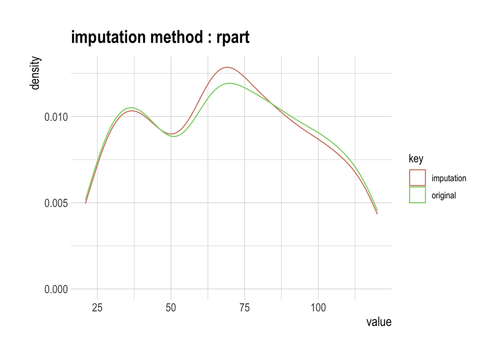

```r
if (requireNamespace("rpart", quietly = TRUE)) {
  income <- imputate_na(carseats, Income, US, method = "rpart")

  # result of imputation
  income

  # summary of imputation
  summary(income)

  # viz of imputation
  plot(income)
} else {
  cat("If you want to use this feature, you need to install the rpart package.\n")
}
```

The following imputes the categorical variable `urban` by the “mice” method.

```r
library(mice)

urban <- imputate_na(carseats, Urban, US, method = "mice")
# result of imputation
urban
```

```
  [1] Yes Yes Yes Yes Yes No  Yes Yes No  No  No  Yes Yes Yes Yes No
 [17] Yes Yes No  Yes Yes No  Yes Yes Yes No  No  Yes Yes Yes Yes Yes
 [33] No  Yes Yes No  No  No  Yes No  No  Yes Yes Yes Yes Yes No  Yes
 [49] Yes Yes Yes Yes Yes Yes No  Yes Yes Yes Yes Yes Yes No  Yes Yes
 [65] No  No  Yes Yes Yes Yes Yes No  Yes No  No  No  Yes No  Yes Yes
 [81] Yes Yes Yes Yes No  No  Yes No  Yes Yes No  Yes Yes Yes Yes Yes
 [97] No  Yes No  No  No  Yes No  Yes Yes Yes No  Yes Yes No  Yes Yes
[113] Yes Yes Yes Yes No  Yes Yes Yes Yes Yes Yes No  Yes No  Yes Yes
[129] Yes No  Yes Yes Yes Yes Yes No  No  Yes Yes No  Yes Yes Yes Yes
[145] No  Yes Yes No  No  Yes No  No  No  No  No  Yes Yes No  Yes No
[161] No  No  Yes No  No  Yes Yes Yes Yes Yes Yes Yes Yes Yes No  Yes
[177] No  Yes No  Yes Yes Yes Yes Yes No  Yes No  Yes Yes No  No  Yes
[193] No  Yes Yes Yes Yes Yes Yes Yes No  Yes No  Yes Yes Yes Yes No
[209] Yes No  No  Yes Yes Yes Yes Yes Yes No  Yes Yes Yes Yes Yes Yes
[225] No  Yes Yes Yes No  No  No  No  Yes No  No  Yes No  Yes Yes Yes
```

[output cut: 25 more lines]

```r
# summary of imputation
summary(urban)
```

```
* Impute missing values based on Multivariate Imputation by Chained Equations
 - method : mice
 - random seed : 43320

* Information of Imputation (before vs after)
     original imputation original_percent imputation_percent
No        115        119            28.75              29.75
Yes       275        281            68.75              70.25
<NA>       10          0             2.50               0.00
```

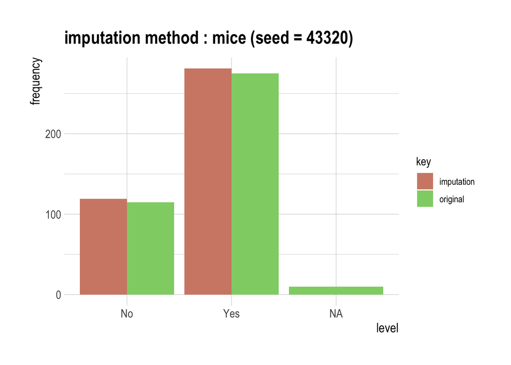

```r
# viz of imputation
plot(urban)
```

## Collaboration with dplyr

The following example imputes the missing value of the `Income` variable, and then calculates the arithmetic mean for each level of `US`. In this case, `dplyr` is used, and it is easily interpreted logically using pipes.

```r
# The mean before and after the imputation of the Income variable
carseats %>%
  mutate(Income_imp = imputate_na(carseats, Income, US, method = "knn")) %>%
  group_by(US) %>%
  summarise(orig = mean(Income, na.rm = TRUE),
            imputation = mean(Income_imp))
```

```
# A tibble: 2 x 3
  US     orig imputation
* <fct> <dbl>      <dbl>
1 No     65.7       65.5
2 Yes    71.3       71.5
```

# Imputation of outliers

## imputes the outliers

`imputate_outlier()` imputes the outliers value. The predictor with outliers supports only numeric variables and supports the following methods.

- predictor is numerical variable
  - “mean” : arithmetic mean
  - “median” : median
  - “mode” : mode
  - “capping” : Impute the upper outliers with 95 percentile, and Impute the bottom outliers with 5 percentile.

`imputate_outlier()` imputes the outliers with the numeric variable `Price` as the “capping” method, as follows. `summary()` summarizes outliers imputation information, and `plot()` visualizes imputation information.

```r
price <- imputate_outlier(carseats, Price, method = "capping")

# result of imputation
price
```

```
  [1] 120.00  83.00  80.00  97.00 128.00  72.00 108.00 120.00 124.00
 [10] 124.00 100.00  94.00 136.00  86.00 118.00 144.00 110.00 131.00
 [19]  68.00 121.00 131.00 109.00 138.00 109.00 113.00  82.00 131.00
 [28] 107.00  97.00 102.00  89.00 131.00 137.00 128.00 128.00  96.00
 [37] 100.00 110.00 102.00 138.00 126.00 124.00  77.00 134.00  95.00
 [46] 135.00  70.00 108.00  98.00 149.00 108.00 108.00 129.00 119.00
 [55] 144.00 154.00  84.00 117.00 103.00 114.00 123.00 107.00 133.00
 [64] 101.00 104.00 128.00  91.00 115.00 134.00  99.00  99.00 150.00
 [73] 116.00 104.00 136.00  92.00  70.00  89.00 145.00  90.00  79.00
 [82] 128.00 139.00  94.00 121.00 112.00 134.00 126.00 111.00 119.00
 [91] 103.00 107.00 125.00 104.00  84.00 148.00 132.00 129.00 127.00
[100] 107.00 106.00 118.00  97.00  96.00 138.00  97.00 139.00 108.00
[109] 103.00  90.00 116.00 151.00 125.00 127.00 106.00 129.00 128.00
[118] 119.00  99.00 128.00 131.00  87.00 108.00 155.00 120.00  77.00
[127] 133.00 116.00 126.00 147.00  77.00  94.00 136.00  97.00 131.00
```

[output cut: 46 more lines]

```r
# summary of imputation
summary(price)
```

```
Impute outliers with capping

* Information of Imputation (before vs after)
            Original  Imputation
n        400.0000000 400.0000000
na         0.0000000   0.0000000
mean     115.7950000 115.8927500
sd        23.6766644  22.6109187
se_mean    1.1838332   1.1305459
IQR       31.0000000  31.0000000
skewness  -0.1252862  -0.0461621
kurtosis   0.4518850  -0.3030578
p00       24.0000000  54.0000000
p01       54.9900000  67.9600000
p05       77.0000000  77.0000000
p10       87.0000000  87.0000000
p20       96.8000000  96.8000000
p25      100.0000000 100.0000000
p30      104.0000000 104.0000000
p40      110.0000000 110.0000000
p50      117.0000000 117.0000000
p60      122.0000000 122.0000000
p70      128.3000000 128.3000000
p75      131.0000000 131.0000000
p80      134.0000000 134.0000000
p90      146.0000000 146.0000000
p95      155.0500000 155.0025000
p99      166.0500000 164.0200000
p100     191.0000000 173.0000000
```

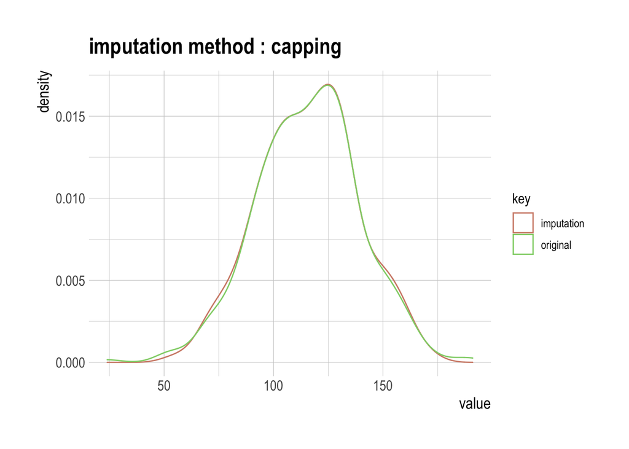

```r
# viz of imputation
plot(price)
```

## Collaboration with dplyr

The following example imputes the outliers of the `Price` variable, and then calculates the arithmetic mean for each level of `US`. In this case, `dplyr` is used, and it is easily interpreted logically using pipes.

```r
# The mean before and after the imputation of the Price variable
carseats %>%
  mutate(Price_imp = imputate_outlier(carseats, Price, method = "capping")) %>%
  group_by(US) %>%
  summarise(orig = mean(Price, na.rm = TRUE),
    imputation = mean(Price_imp, na.rm = TRUE))
```

```
# A tibble: 2 x 3
  US     orig imputation
* <fct> <dbl>      <dbl>
1 No     114.       114.
2 Yes    117.       117.
```

# Binning

## Binning of individual variables

`binning()` transforms a numeric variable into a categorical variable by binning it. The following types of binning are supported.

- “quantile” : categorize using quantile to include the same frequencies
- “equal” : categorize to have equal length segments
- “pretty” : categorized into moderately good segments
- “kmeans” : categorization using K-means clustering
- “bclust” : categorization using bagged clustering technique

Here are some examples of how to bin `Income` using `binning()`.:

```r
# Binning the carat variable. default type argument is "quantile"
bin <- binning(carseats$Income)
# Print bins class object
bin
```

```
binned type: quantile
number of bins: 10
x
 [21,31.36667]  (31.36667,40]        (40,50]        (50,62]
            38             40             37             40
       (62,69]        (69,78]  (78,87.56667]  (87.56667,98]
            40             34             37             41
 (98,108.6333] (108.6333,120]           <NA>
            35             38             20
```

```r
# Summarize bins class object
summary(bin)
```

```
           levels freq   rate
1   [21,31.36667]   38 0.0950
2   (31.36667,40]   40 0.1000
3         (40,50]   37 0.0925
4         (50,62]   40 0.1000
5         (62,69]   40 0.1000
6         (69,78]   34 0.0850
7   (78,87.56667]   37 0.0925
8   (87.56667,98]   41 0.1025
9   (98,108.6333]   35 0.0875
10 (108.6333,120]   38 0.0950
11           <NA>   20 0.0500
```

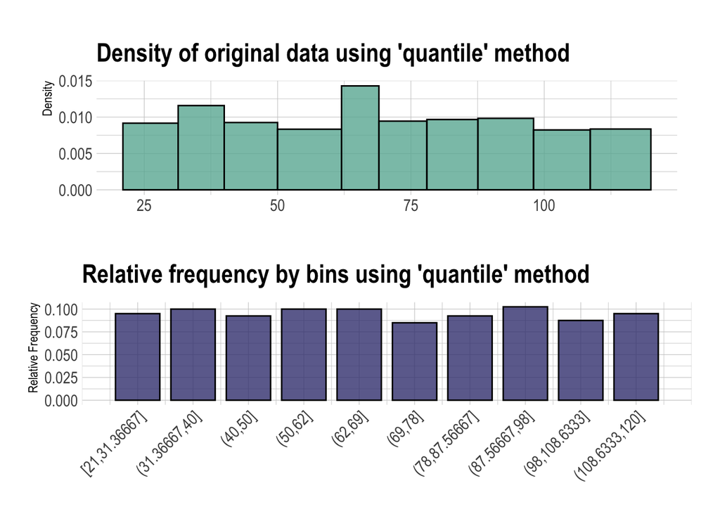

```r
# Plot bins class object
plot(bin)
```

```r
# Using labels argument
bin <- binning(carseats$Income, nbins = 4,
              labels = c("LQ1", "UQ1", "LQ3", "UQ3"))
bin
```

```
binned type: quantile
number of bins: 4
x
 LQ1  UQ1  LQ3  UQ3 <NA>
  98   97   91   94   20
```

```r
# Using another type argument
binning(carseats$Income, nbins = 5, type = "equal")
```

```
binned type: equal
number of bins: 5
x
   [21,40.8]  (40.8,60.6]  (60.6,80.4] (80.4,100.2]  (100.2,120]
          78           68           92           79           63
        <NA>
          20
```

```r
binning(carseats$Income, nbins = 5, type = "pretty")
```

```
binned type: pretty
number of bins: 5
x
  [20,40]   (40,60]   (60,80]  (80,100] (100,120]      <NA>
       78        68        92        79        63        20
```

```r
if (requireNamespace("classInt", quietly = TRUE)) {
  binning(carseats$Income, nbins = 5, type = "kmeans")
  binning(carseats$Income, nbins = 5, type = "bclust")
} else {
  cat("If you want to use this feature, you need to install the classInt package.\n")
}
```

```
binned type: bclust
number of bins: 5
x
  [21,36.5] (36.5,57.5]   (57.5,85]  (85,108.5] (108.5,120]
         65          67         129          81          38
       <NA>
         20
```

```r
# Extract the binned results
extract(bin)
```

```
  [1] LQ3  UQ1  LQ1  UQ3  UQ1  UQ3  UQ3  LQ3  UQ3  UQ3  LQ3  UQ3  LQ1
 [14] <NA> UQ3  UQ3  LQ1  LQ3  UQ3  LQ3  LQ3  LQ1  UQ1  LQ1  UQ3  LQ1
 [27] UQ3  UQ3  LQ3  UQ3  UQ3  UQ1  LQ1  LQ1  UQ1  LQ3  LQ3  LQ1  LQ3
 [40] UQ1  UQ3  UQ1  UQ1  LQ1  LQ3  UQ1  LQ3  UQ3  UQ1  UQ3  LQ1  LQ3
 [53] LQ1  UQ1  UQ3  LQ3  LQ3  LQ3  UQ3  LQ3  UQ3  LQ1  UQ1  LQ3  UQ1
 [66] LQ1  LQ3  UQ1  UQ1  UQ1  LQ3  UQ1  UQ1  LQ3  UQ1  UQ3  LQ3  LQ3
 [79] UQ1  UQ1  UQ3  LQ3  LQ3  LQ1  LQ1  UQ3  LQ3  UQ1  LQ1  <NA> <NA>
 [92] UQ1  UQ3  LQ1  UQ3  LQ1  LQ1  LQ3  LQ3  UQ1  UQ1  UQ3  LQ1  LQ3
[105] UQ3  UQ3  LQ1  UQ3  LQ3  UQ1  UQ1  UQ3  UQ3  LQ1  LQ3  LQ1  LQ3
[118] <NA> LQ3  UQ3  UQ3  LQ3  UQ3  UQ3  UQ3  LQ3  UQ1  UQ1  UQ3  UQ3
[131] LQ3  UQ1  LQ3  UQ3  LQ1  UQ3  <NA> LQ1  UQ3  UQ1  UQ1  LQ1  LQ3
[144] LQ3  UQ1  UQ1  LQ3  UQ1  UQ3  UQ3  LQ3  UQ1  <NA> LQ1  UQ1  LQ3
[157] LQ1  UQ1  LQ3  UQ1  LQ1  LQ1  LQ3  UQ1  UQ1  UQ1  UQ1  LQ3  LQ3
[170] LQ1  LQ1  UQ3  UQ3  LQ3  LQ1  LQ3  UQ3  LQ3  <NA> LQ1  UQ3  LQ3
[183] UQ1  LQ3  LQ1  UQ3  UQ1  LQ1  LQ1  UQ3  LQ1  LQ1  LQ1  LQ3  <NA>
```

[output cut: 17 more lines]

```r
# -------------------------
# Using pipes & dplyr
# -------------------------
library(dplyr)

carseats %>%
 mutate(Income_bin = binning(carseats$Income) %>%
                     extract()) %>%
 group_by(ShelveLoc, Income_bin) %>%
 summarise(freq = n()) %>%
 arrange(desc(freq)) %>%
 head(10)
```

```
# A tibble: 10 x 3
# Groups:   ShelveLoc [1]
   ShelveLoc Income_bin      freq
   <fct>     <ord>          <int>
 1 Medium    [21,31.36667]     25
 2 Medium    (62,69]           23
 3 Medium    (50,62]           22
 4 Medium    (31.36667,40]     21
 5 Medium    (40,50]           20
 6 Medium    (69,78]           20
 7 Medium    (108.6333,120]    20
 8 Medium    (78,87.56667]     19
 9 Medium    (87.56667,98]     19
10 Medium    (98,108.6333]     19
```

## Optimal Binning

`binning_by()` transforms a numeric variable into a categorical variable by optimal binning. This method is often used when developing a `scorecard model`.

The following `binning_by()` example optimally binning `Advertising` considering the target variable `US` with a binary class.

```r
library(dplyr)

# optimal binning using character
bin <- binning_by(carseats, "US", "Advertising")

# optimal binning using name
bin <- binning_by(carseats, US, Advertising)
bin
```

```
binned type: optimal
number of bins: 3
x
[-1,0]  (0,6] (6,29]
   144     69    187
```

```r
# summary optimal_bins class
summary(bin)
```

```
── Binning Table ──────────────────────── Several Metrics ──
     Bin CntRec CntPos CntNeg RatePos RateNeg    Odds      WoE
1 [-1,0]    144     19    125 0.07364 0.88028  0.1520 -2.48101
2  (0,6]     69     54     15 0.20930 0.10563  3.6000  0.68380
3 (6,29]    187    185      2 0.71705 0.01408 92.5000  3.93008
4  Total    400    258    142 1.00000 1.00000  1.8169       NA
       IV     JSD     AUC
1 2.00128 0.20093 0.03241
2 0.07089 0.00869 0.01883
3 2.76272 0.21861 0.00903
4 4.83489 0.42823 0.06028

── General Metrics ─────────────────────────────────────────
● Gini index                       :  -0.87944
● IV (Jeffrey)                     :  4.83489
● JS (Jensen-Shannon) Divergence   :  0.42823
● Kolmogorov-Smirnov Statistics    :  0.80664
● HHI (Herfindahl-Hirschman Index) :  0.37791
● HHI (normalized)                 :  0.06687
● Cramer's V                       :  0.81863

── Significance Tests ──────────────────── Chisquare Test ──
   Bin A  Bin B statistics      p_value
1 [-1,0]  (0,6]   87.67064 7.731349e-21
2  (0,6] (6,29]   34.73349 3.780706e-09
```

```r
# performance table
attr(bin, "performance")
```

```
     Bin CntRec CntPos CntNeg CntCumPos CntCumNeg RatePos RateNeg
1 [-1,0]    144     19    125        19       125 0.07364 0.88028
2  (0,6]     69     54     15        73       140 0.20930 0.10563
3 (6,29]    187    185      2       258       142 0.71705 0.01408
4  Total    400    258    142        NA        NA 1.00000 1.00000
  RateCumPos RateCumNeg    Odds   LnOdds      WoE      IV     JSD
1    0.07364    0.88028  0.1520 -1.88387 -2.48101 2.00128 0.20093
2    0.28295    0.98592  3.6000  1.28093  0.68380 0.07089 0.00869
3    1.00000    1.00000 92.5000  4.52721  3.93008 2.76272 0.21861
4         NA         NA  1.8169  0.59713       NA 4.83489 0.42823
      AUC
1 0.03241
2 0.01883
3 0.00903
4 0.06028
```

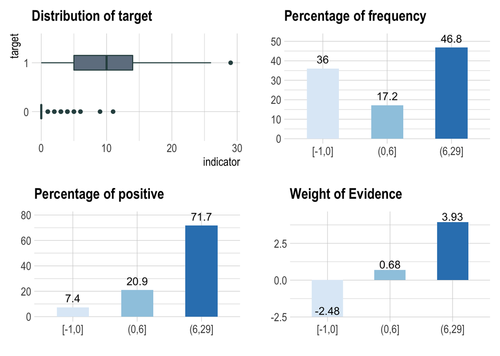

```r
# visualize optimal_bins class
plot(bin)
```

```r
# extract binned results
extract(bin) %>%
  head(20)
```

```
 [1] (6,29] (6,29] (6,29] (0,6]  (0,6]  (6,29] [-1,0] (6,29] [-1,0]
[10] [-1,0] (6,29] (0,6]  (0,6]  (6,29] (6,29] (0,6]  [-1,0] (6,29]
[19] [-1,0] (6,29]
Levels: [-1,0] < (0,6] < (6,29]
```

# Diagnose binned variable

## Performance binned variable

`performance_bin()` calculates metrics to evaluate the performance of binned variable for binomial classification model.

```r
# Generate data for the example
heartfailure2 <- heartfailure

set.seed(123)
heartfailure2[sample(seq(NROW(heartfailure2)), 5), "creatinine"] <- NA

# Change the target variable to 0(negative) and 1(positive).
heartfailure2$death_event_2 <- ifelse(heartfailure2$death_event %in% "Yes", 1, 0)

# Binnig from creatinine to platelets_bin.
breaks <- c(0,  1,  2, 10)
heartfailure2$creatinine_bin <- cut(heartfailure2$creatinine, breaks)

# Diagnose performance binned variable
perf <- performance_bin(heartfailure2$death_event_2, heartfailure2$creatinine_bin)
perf
```

```
     Bin CntRec CntPos CntNeg CntCumPos CntCumNeg RatePos RateNeg
1  (0,1]    128     24    104        24       104 0.25000 0.51232
2  (1,2]    132     51     81        75       185 0.53125 0.39901
3 (2,10]     34     21     13        96       198 0.21875 0.06404
4   <NA>      5      0      5        96       203 0.00000 0.02463
5  Total    299     96    203        NA        NA 1.00000 1.00000
  RateCumPos RateCumNeg    Odds   LnOdds      WoE      IV     JSD
1    0.25000    0.51232 0.23077 -1.46634 -0.71748 0.18821 0.02303
2    0.78125    0.91133 0.62963 -0.46262  0.28623 0.03785 0.00472
3    1.00000    0.97537 1.61538  0.47957  1.22843 0.19005 0.02237
4    1.00000    1.00000 0.00000     -Inf       NA      NA      NA
5         NA         NA 0.47291 -0.74886       NA      NA      NA
      AUC
1 0.06404
2 0.20574
3 0.05704
4 0.02463
5 0.35145
```

## Summarizing performance

`summary.performance_bin()` summarize metrics to evaluate the performance of binomial classification model.

```r
summary(perf)
```

```
── Binning Table ──────────────────────── Several Metrics ──
     Bin CntRec CntPos CntNeg RatePos RateNeg    Odds      WoE
1  (0,1]    128     24    104 0.25000 0.51232 0.23077 -0.71748
2  (1,2]    132     51     81 0.53125 0.39901 0.62963  0.28623
3 (2,10]     34     21     13 0.21875 0.06404 1.61538  1.22843
4   <NA>      5      0      5 0.00000 0.02463 0.00000       NA
5  Total    299     96    203 1.00000 1.00000 0.47291       NA
       IV     JSD     AUC
1 0.18821 0.02303 0.06404
2 0.03785 0.00472 0.20574
3 0.19005 0.02237 0.05704
4      NA      NA 0.02463
5      NA      NA 0.35145

── General Metrics ─────────────────────────────────────────
● Gini index                       :  -0.29711
● IV (Jeffrey)                     :  NA
● JS (Jensen-Shannon) Divergence   :  NA
● Kolmogorov-Smirnov Statistics    :  0.26232
● HHI (Herfindahl-Hirschman Index) :  0.39137
● HHI (normalized)                 :  0.1885
● Cramer's V                       :  0.30024

── Significance Tests ──────────────────── Chisquare Test ──
  Bin A  Bin B statistics      p_value
1 (0,1]  (1,2]  12.520885 0.0004024283
2 (1,2] (2,10]   5.888296 0.0152418462
```

## Visualize performance

`plot.performance_bin()` visualize metrics to evaluate the performance of binomial classification model.

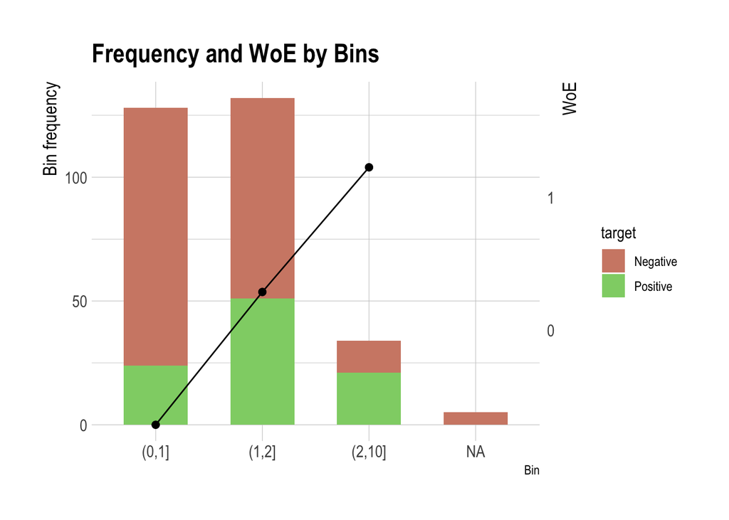

```r
plot(perf)
```

# Transformation

## Introduction transformation

`transform()` performs data transformation. Only numeric variables are supported, and the following methods are provided.

- Standardization
  - “zscore” : z-score transformation. (x - mu) / sigma
  - “minmax” : minmax transformation. (x - min) / (max - min)
- Resolving Skewness
  - “log” : log transformation. log(x)
  - “log+1” : log transformation. log(x + 1). Used for values that contain 0.
  - “sqrt” : square root transformation.
  - “1/x” : 1 / x transformation
  - “x^2” : x square transformation
  - “x^3” : x^3 square transformation

## Standardization

Use the methods “zscore” and “minmax” to perform standardization.

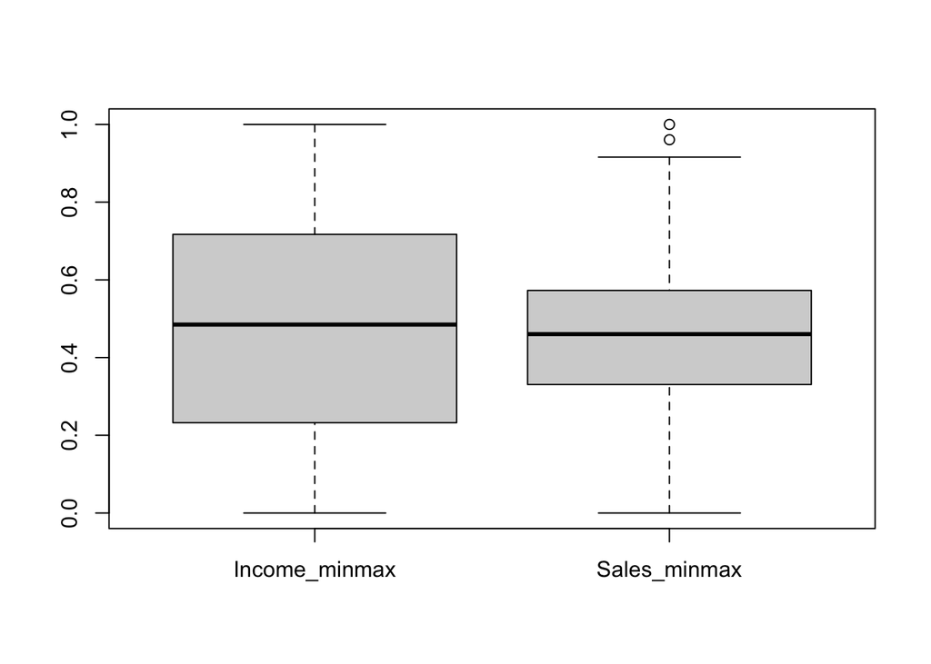

```r
carseats %>%
  mutate(Income_minmax = transform(carseats$Income, method = "minmax"),
    Sales_minmax = transform(carseats$Sales, method = "minmax")) %>%
  select(Income_minmax, Sales_minmax) %>%
  boxplot()
```

## Resolving Skewness data

`find_skewness()` searches for variables with skewed data. This function finds data skewed by search conditions and calculates skewness.

```r
# find index of skewed variables
find_skewness(carseats)
```

```
[1] 4
```

```r
# find names of skewed variables
find_skewness(carseats, index = FALSE)
```

```
[1] "Advertising"
```

```r
# compute the skewness
find_skewness(carseats, value = TRUE)
```

```
      Sales   CompPrice      Income Advertising  Population
      0.185      -0.043       0.036       0.637      -0.051
      Price         Age   Education
     -0.125      -0.077       0.044
```

```r
# compute the skewness & filtering with threshold
find_skewness(carseats, value = TRUE, thres = 0.1)
```

```
      Sales Advertising       Price
      0.185       0.637      -0.125
```

The skewness of `Advertising` is 0.637. This means that the distribution of data is somewhat inclined to the left. So, for normal distribution, use `transform()` to convert to “log” method as follows. `summary()` summarizes transformation information, and `plot()` visualizes transformation information.

```r
Advertising_log = transform(carseats$Advertising, method = "log")

# result of transformation
head(Advertising_log)
```

```
[1] 2.397895 2.772589 2.302585 1.386294 1.098612 2.564949
```

```r
# summary of transformation
summary(Advertising_log)
```

```
* Resolving Skewness with log

* Information of Transformation (before vs after)
            Original Transformation
n        400.0000000    400.0000000
na         0.0000000      0.0000000
mean       6.6350000           -Inf
sd         6.6503642            NaN
se_mean    0.3325182            NaN
IQR       12.0000000            Inf
skewness   0.6395858            NaN
kurtosis  -0.5451178            NaN
p00        0.0000000           -Inf
p01        0.0000000           -Inf
p05        0.0000000           -Inf
p10        0.0000000           -Inf
p20        0.0000000           -Inf
p25        0.0000000           -Inf
p30        0.0000000           -Inf
p40        2.0000000      0.6931472
p50        5.0000000      1.6094379
p60        8.4000000      2.1265548
p70       11.0000000      2.3978953
p75       12.0000000      2.4849066
p80       13.0000000      2.5649494
p90       16.0000000      2.7725887
p95       19.0000000      2.9444390
p99       23.0100000      3.1359198
p100      29.0000000      3.3672958
```

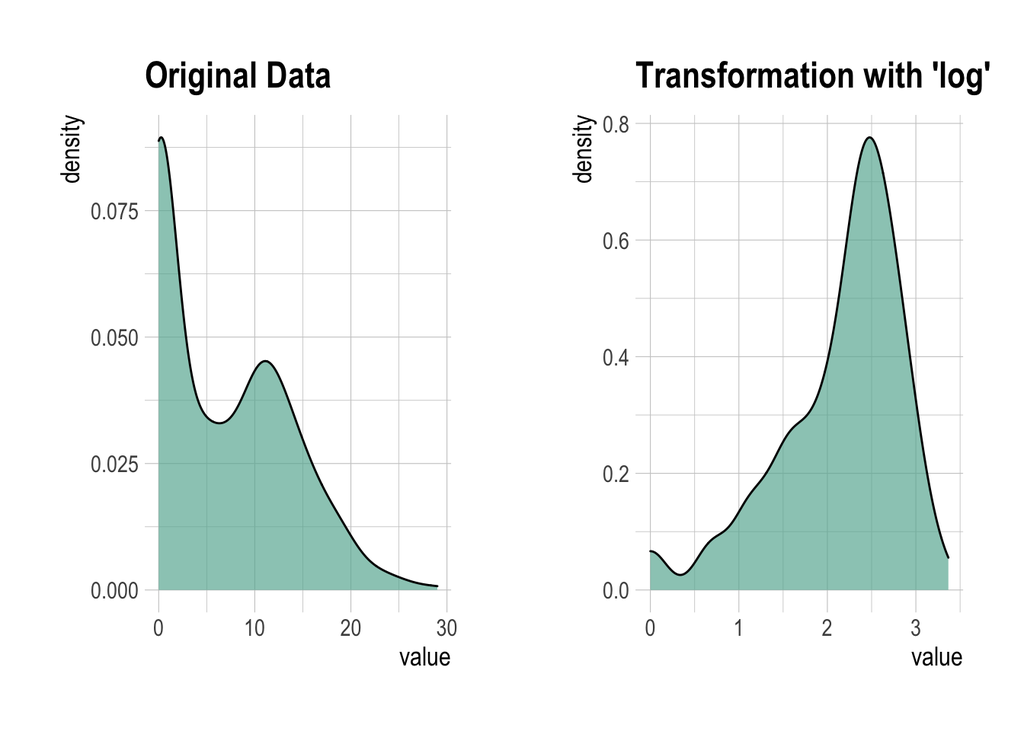

```r
# viz of transformation
plot(Advertising_log)
```

It seems that the raw data contains 0, as there is a -Inf in the log converted value. So this time, convert it to “log+1”.

```r
Advertising_log <- transform(carseats$Advertising, method = "log+1")

# result of transformation
head(Advertising_log)
```

```
[1] 2.484907 2.833213 2.397895 1.609438 1.386294 2.639057
```

```r
# summary of transformation
summary(Advertising_log)
```

```
* Resolving Skewness with log+1

* Information of Transformation (before vs after)
            Original Transformation
n        400.0000000   400.00000000
na         0.0000000     0.00000000
mean       6.6350000     1.46247709
sd         6.6503642     1.19436323
se_mean    0.3325182     0.05971816
IQR       12.0000000     2.56494936
skewness   0.6395858    -0.19852549
kurtosis  -0.5451178    -1.66342876
p00        0.0000000     0.00000000
p01        0.0000000     0.00000000
p05        0.0000000     0.00000000
p10        0.0000000     0.00000000
p20        0.0000000     0.00000000
p25        0.0000000     0.00000000
p30        0.0000000     0.00000000
p40        2.0000000     1.09861229
p50        5.0000000     1.79175947
p60        8.4000000     2.23936878
p70       11.0000000     2.48490665
p75       12.0000000     2.56494936
p80       13.0000000     2.63905733
p90       16.0000000     2.83321334
p95       19.0000000     2.99573227
p99       23.0100000     3.17846205
p100      29.0000000     3.40119738
```

```r
# viz of transformation
# plot(Advertising_log)
```

# Creating a data transformation report

`transformation_report()` generates a data transformation report for all the variables in the data frame or objects that inherit the data frame (`tbl_df`, `tbl`, etc.).

`transformation_report()` generates a data transformation report in two forms:

- pdf file based on Latex
- html file

The contents of the report are as follows.:

- Imputation
  - Missing Values
    - Missing values imputation information
    - (variable names)
  - Outliers
    - Outliers imputation information
    - (variable names)
- Resolving Skewness
  - Skewed variables information
    - (variable names)
- Binning
  - Numerical Variables for Binning
  - Binning
    - (variable names)
  - Optimal Binning
    - (variable names)

The following generates a data transformation report for `carseats`. The file format is pdf, and the file name is `Transformation_Report.pdf`.

```r
carseats %>%
  transformation_report(target = US)
```

The following generates a report in html format called `transformation_carseats.html`.

```r
carseats %>%
  transformation_report(target = US, output_format = "html",
    output_file = "transformation_carseats.html")
```

Data transformation reports are automated reports to assist in the data transformation process. Design data conversion scenarios by referring to the report results.

### Data transformation report contents

#### Contents of pdf file

- The cover of the report is shown in the following figure.

[figure not shown]

- The report’s agenda is shown in the following figure.

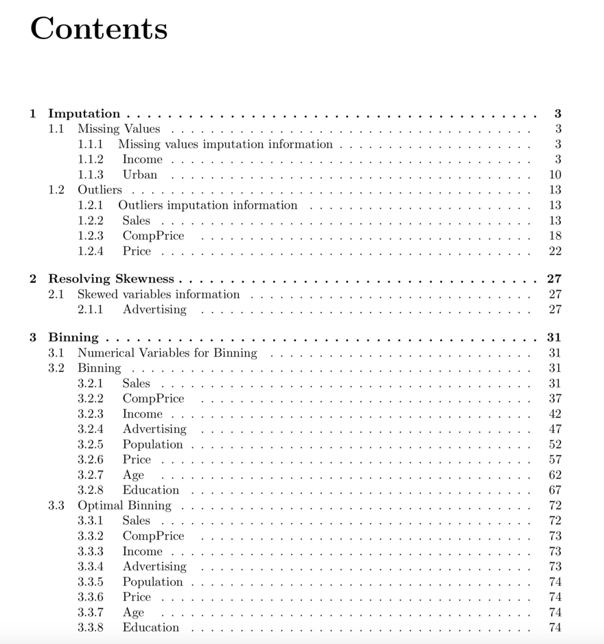

- Much of the information is displayed in tables and visualization results in reports. An example is shown in the following figure.

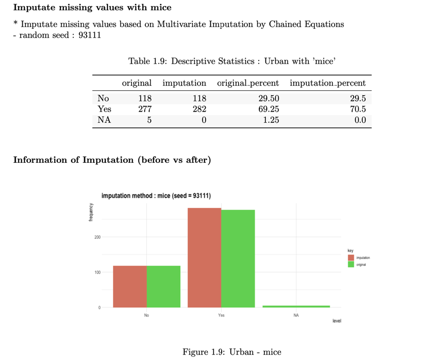